# Severe Weather Events in the United States

Severe weather events can cause both public health and economic problems. This report explores the U.S. National Oceanic and Atmospheric Administration’s (NOAA) storm database in order to answer the following two questions:

1. Which types of events are most harmful with respect to population health?
2. Which types of events have the greatest economic consequences?

## Data Processing

The analysis was performed using R version 3.1.2 (2014-10-31) along with a group of supporting packages available in the [Comprehensive R Archive Network](http://cran.r-project.org/) (CRAN). The first step in the analysis is to load all the required packages in R:

```r
packages <- c("dplyr", "lubridate", "stringi", "stringdist", "ggplot2", "tidyr")
for (package in packages) {
    library(package, character.only = TRUE, warn.conflicts = FALSE)
}
```

The data used in the analysis is contained in a bzip2-compressed file containing a comma-separated-value (CSV) file, which can be downloaded from the following link:

https://d396qusza40orc.cloudfront.net/repdata%2Fdata%2FStormData.csv.bz2

Additional information about some of the variables is provided in the [Storm Data Preparation](https://d396qusza40orc.cloudfront.net/repdata%2Fpeer2_doc%2Fpd01016005curr.pdf) and [Storm Data FAQ](https://d396qusza40orc.cloudfront.net/repdata%2Fpeer2_doc%2FNCDC%20Storm%20Events-FAQ%20Page.pdf) documents.

The storm database can be downloaded and loaded into R as follows:

```r
original_data_url <- "https://d396qusza40orc.cloudfront.net/repdata%2Fdata%2FStormData.csv.bz2"
original_data_bz2 <- "StormData.csv.bz2"
if (!file.exists(original_data_bz2)) {
    download.file(original_data_url, original_data_bz2, method = "curl")
    download_date <- Sys.time()
} else {
    download_date <- file.info(original_data_bz2)[, "ctime"]
}
original_data <- read.csv(original_data_bz2, stringsAsFactors = FALSE)
```

The data used in this report was downloaded on November 23, 2014 and it contains 902297 rows and 37 columns. Further processing was done in order to transform this data into a tidy dataset more suitable for this particular analysis.

This analysis focuses only on a fraction of this original dataset: the columns `BGN_DATE`, `EVTYPE`, `FATALITIES`, `INJURIES`, `PROPDMG`, `PROPDMGEXP`, `CROPDMG`, and `CROPDMGEXP`. These columns provide the date when a severe weather events began, the type of event, the number of fatalities, injuries, and information about the costs in property and crop damages. The analysis studies weather events which have had a negative impact on the population health or the economy, therefore events without any reported values on the `FATALITIES`, `INJURIES`, `PROPDMG` and `CROPDMG` columns are discarded.

There is a considerable variability in the way the weather event types are described in the `EVTYPE` column. The *Storm Data Preparation* manual describes 48 possible event types to be encoded in the database, but the actual database contains 985 different values. Aiming to provide a more consistent description of the events, the values of the `EVTYPE` column in the original database have been mapped to the 48 possible event types described in the *Storm Data Preparation* manual choosing the closest representation according to the Levenshtein edit distance. It is important to note that this procedure may introduce some bias in the data caused by incorrect labels being assigned to the event types.

Also as part of the data processing, the `BGN_DATE` column is converted to a structure that can be easily handled in R, and the population and crop damages are expressed as single numerical values (combining the mantissa and the exponent). All these steps to transform the data are implemented in the following R code fragment:

```r
event_types <- c("Astronomical Low Tide", "Avalanche", "Blizzard",
    "Coastal Flood", "Cold/Wind Chill", "Debris Flow", "Dense Fog",
    "Dense Smoke", "Drought", "Dust Devil", "Dust Storm", "Excessive Heat",
    "Extreme Cold/Wind Chill", "Flash Flood", "Flood", "Frost/Freeze",
    "Funnel Cloud", "Freezing Fog", "Hail", "Heat", "Heavy Rain", "Heavy Snow",
    "High Surf", "High Wind", "Hurricane (Typhoon)", "Ice Storm",
    "Lake-Effect Snow", "Lakeshore Flood", "Lightning", "Marine Hail",
    "Marine High Wind", "Marine Strong Wind", "Marine Thunderstorm Wind",
    "Rip Current", "Seiche", "Sleet", "Storm Surge/Tide", "Strong Wind",
    "Thunderstorm Wind", "Tornado", "Tropical Depression", "Tropical Storm",
    "Tsunami", "Volcanic Ash", "Waterspout", "Wildfire", "Winter Storm",
    "Winter Weather")

normalize_event_type <- Vectorize(function(event_type) {
    event_type <- event_type %>%
        # If alternatives are given, take the first one:
        stri_extract_first_regex("^[^/]+") %>%
        # Expand some abbreviations:
        stri_replace_first_fixed("TSTM", "THUNDERSTORM") %>%
        # Convert to title case:
        stri_trans_totitle()
    distances <- stringdist(event_type, event_types, method = "lv")
    event_types[which.min(distances)]
})

numeric_exp <- function(letter) {
    recognized_exp <- c(H = 2, h = 2, K = 3, k = 3, M = 6, m = 6, B = 9, b = 9)
    letter[!letter %in% names(recognized_exp)] <- ""
    sapply(letter, function(l) do.call(switch, c(list(l), recognized_exp, 0)))
}

tidy_data <- original_data %>%
    # Select a subset of the columns:
    select(BGN_DATE, EVTYPE, FATALITIES, INJURIES,
           PROPDMG, PROPDMGEXP, CROPDMG, CROPDMGEXP) %>%
    # Filter events with nonzero values in at least one of the columns
    # FATALITIES, INJURIES, PROPDMG or CROPDMG:
    filter(FATALITIES > 0 | INJURIES > 0 | PROPDMG > 0 | CROPDMG > 0) %>%
    # Normalize EVTYPE:
    mutate(EVTYPE = factor(normalize_event_type(EVTYPE))) %>%
    # Convert BGN_DATE to a vector of class POSIXct:
    mutate(BGN_DATE = mdy_hms(BGN_DATE)) %>%
    # Compute the numerical values of PROPDMG and CROPDMG:
    mutate(PROPDMG = PROPDMG * 10^numeric_exp(PROPDMGEXP)) %>%
    mutate(CROPDMG = CROPDMG * 10^numeric_exp(CROPDMGEXP)) %>%
    select(-PROPDMGEXP, -CROPDMGEXP)

colnames(tidy_data) <- c("date", "event_type", "fatalities", "injuries",
                         "property_damage", "crop_damage")
```

The resulting tidy dataset contains 254633 rows and 6 columns. It contains information about events that took place between 1950 and 2011. The following histogram summarizes the information in the tidy dataset. It evidences that in the earlier years of the database there are fewer events recorded, most likely due to a lack of good records.

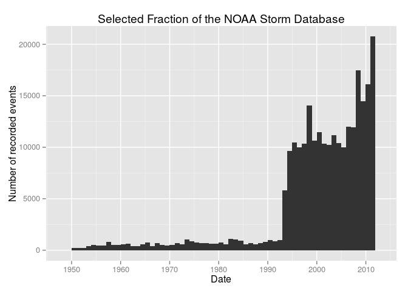

```r
ggplot(tidy_data, aes(x = date)) +
    geom_bar(binwidth = as.numeric(duration(1, "year"))) +
    labs(title = "Selected Fraction of the NOAA Storm Database",
         x = "Date", y = "Number of recorded events")
```

## Results

This section presents the results supporting the answers to the questions that motivated the analysis.

### Damages to the Population Health

The tidy dataset was analyzed in order to get some insights about which types of events are most harmful with respect to population health. Both fatalities and injuries are considered separately, and for each case the top-5 event types are reported. The following R code summarizes the data and generates the figure shown below.

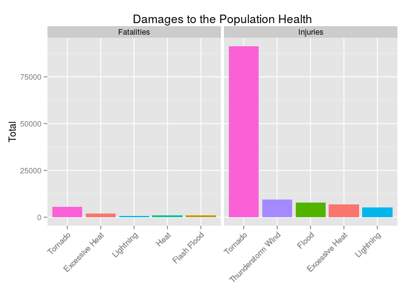

```r
population_data <- tidy_data %>%
    group_by(event_type) %>%
    summarize(Fatalities = sum(fatalities), Injuries = sum(injuries)) %>%
    gather(damage_type, damage_count, -event_type) %>%
    group_by(damage_type) %>%
    arrange(desc(damage_count)) %>%
    filter(row_number() <= 5)

ggplot(population_data, aes(x = reorder(event_type, -damage_count),
                            y = damage_count, fill = event_type)) +
    geom_bar(stat = "identity") +
    facet_wrap(~ damage_type, scales = "free_x") +
    theme(legend.position = "none",
          axis.text.x = element_text(angle = 45, hjust = 1)) +
    labs(title = "Damages to the Population Health", x = NULL, y = "Total")
```

As we may see from the plot, the most harmful severe weather event to the population health are tornadoes, as they are responsible for the largest number of both fatalities and injuries. Heat, lightning and flood are other weather events that cause important damages to the population.

### Damages to the Economy

A similar study was performed regarding the events with the greatest economic consequences. In this case, the damages to the economy were measured as the combined cost in property and crop damages. The following R code fragment computes the top-10 event types with the greatest economic consequences and generates the figure shown below.

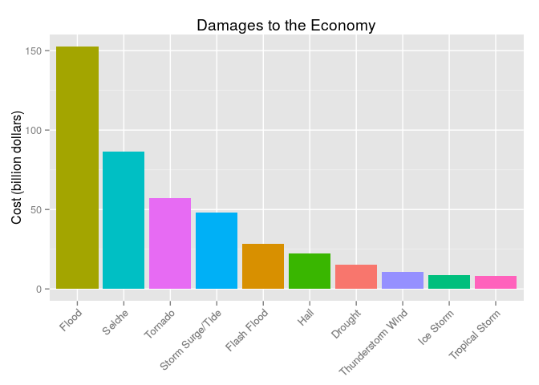

```r
economic_data <- tidy_data %>%
    group_by(event_type) %>%
    summarize(total_damages = sum(property_damage) + sum(crop_damage)) %>%
    arrange(desc(total_damages)) %>%
    filter(row_number() <= 10)

ggplot(economic_data, aes(x = reorder(event_type, -total_damages),
                         y = total_damages / 10^9, fill = event_type)) +
    geom_bar(stat = "identity") +
    theme(legend.position = "none",
          axis.text.x = element_text(angle = 45, hjust = 1)) +
    labs(title = "Damages to the Economy", x = NULL, y = "Cost (billion dollars)")
```

The figure evidences that flood causes the greatest economic consequences in the U.S., inflicting considerably more property and crop damages than the other severe weather events.

## Conclusions

From the results of the analysis, we can conclude that tornadoes and floods are among the severe weather events causing the most important health and economic damages in the U.S.